# ---

title: "Analyse_donnees"

## output: html_document

L'objectif de ce notebook est de mieux comprendre les données et analyses de l'article *Mutation dynamics and fitness effects followed in single cells*, par Lydia Robert, Jean Ollion, Jerome Robert, Xiaohu Song, Ivan Matic et Marina Elez (Science, 2018).

# Exploration des données

```r
library("ggplot2")
```

## Données d'Accumulation de Mutations : data_microMA

### Description des fichiers

The folder contains 4 files giving the evolution of growth rate during one representative $\mu$MA experiment for 4 different strains, *mutH*, *mutT*, WT, MF1 (dataset*microMA*...) . Each column contains the values of one variable (time, generation or growth rate) for each time step for the mother cell of a single microchannel. The first two lines (i.e. first two values for each column) give respectively the index of the field of view and the index of the microchannel (~15channels for each field of view).

```r
microMA_WT <- read.csv2("doi_10/All_data/data_microMA/dataset_microMA_WT.csv")
microMA_MutH <- read.csv2("doi_10/All_data/data_microMA/dataset_microMA_MutH.csv")
microMA_MutT <- read.csv2("doi_10/All_data/data_microMA/dataset_microMA_MutT.csv")
microMA_MF1 <- read.csv2("doi_10/All_data/data_microMA/dataset_microMA_MF1.csv")

# Split the channel information (first 2 lines) from the growth rates
microMA_WT_channels <- microMA_WT[c(1,2),]
microMA_WT <- microMA_WT[-c(1,2),]
microMA_MutH_channels <- microMA_MutH[c(1,2),]
microMA_MutH <- microMA_MutH[-c(1,2),]
microMA_MutT_channels <- microMA_MutT[c(1,2),]
microMA_MutT <- microMA_MutT[-c(1,2),]
microMA_MF1_channels <- microMA_MF1[c(1,2),]
microMA_MF1 <- microMA_MF1[-c(1,2),]

microMA_MutH[1:6,1:9]
```

A data.frame: 6 × 9

|  | time <int> | generation <int> | growth.rate <dbl> | time.1 <int> | generation.1 <int> | growth.rate.1 <dbl> | time.2 <int> | generation.2 <int> | growth.rate.2 <dbl> |
| --- | --- | --- | --- | --- | --- | --- | --- | --- | --- |
| 3 | 0 | 1 | 0.03526965 | 0 | 1 | 0.03202591 | 0 | 1 | 0.02811950 |
| 4 | 4 | 1 | 0.03526965 | 4 | 1 | 0.03202591 | 4 | 1 | 0.02811950 |
| 5 | 8 | 2 | 0.03247045 | 8 | 1 | 0.03202591 | 8 | 2 | 0.02680181 |
| 6 | 12 | 2 | 0.03247045 | 12 | 1 | 0.03202591 | 12 | 2 | 0.02680181 |
| 7 | 16 | 2 | 0.03247045 | 16 | 2 | 0.03367152 | 16 | 2 | 0.02680181 |
| 8 | 20 | 2 | 0.03247045 | 20 | 2 | 0.03367152 | 20 | 2 | 0.02680181 |

The folder also contains 4 files giving data on mortality of the mother cell for these experiments and one file with the mortality data for one representative experiment with the pMQ strain (induced with arabinose). For WT and mutH strains, the first 2 columns gives the index of the field of view and the index of the microchannel. The two last columns for WT and mutH and the two columns for mutT, MF1 and pMQ indicates the final state of the mother cell and the last frame. Several cases can occur :

1. the mother cell can die during the experiment (final state=0, last frame=frame of the last division),
2. it can stay alive and be imaged until the end of the experiment (final state=2, last frame=last frame of the movie),
3. ?
4. or imaging can stop before the end of the experiment for instance if the cells escape the channel (final state=4, last frame=last frame where the mother cell is imaged).

```r
mortality_WT <- read.csv2("doi_10/All_data/data_microMA/mortality_WT.csv")
mortality_MutH <- read.csv2("doi_10/All_data/data_microMA/mortality_MutH.csv")
mortality_MutT <- read.csv2("doi_10/All_data/data_microMA/mortality_mutT.csv")
mortality_MF1 <- read.csv2("doi_10/All_data/data_microMA/mortality_MF1.csv")
mortality_pMQ <- read.csv2("doi_10/All_data/data_microMA/mortality_pMQara.csv")

# Name columns
names(mortality_WT) <- c("Field.view", "Microchannel", "Final.state", "Final.frame")
names(mortality_MutH) <- c("Field.view", "Microchannel", "Final.state", "Final.frame")

# Remove NA columns
mortality_MutT <- mortality_MutT[-which(sapply(mortality_MutT, function(x)all(is.na(x))))]
mortality_pMQ <- mortality_pMQ[-which(sapply(mortality_pMQ, function(x)all(is.na(x))))]

# Consider the final state as a factor
mortality_WT$Final.state <- as.factor(mortality_WT$Final.state)
mortality_MutH$Final.state <- as.factor(mortality_MutH$Final.state)
mortality_MutT$Final.state <- as.factor(mortality_MutT$Final.state)
mortality_MF1$Final.state <- as.factor(mortality_MF1$Final.state)
mortality_pMQ$Final.state <- as.factor(mortality_pMQ$Final.state)

# Remove lines with NAs
mortality_WT_NA <- mortality_WT[is.na(mortality_WT$Final.state),]
mortality_WT <- mortality_WT[!is.na(mortality_WT$Final.state),]
mortality_MutH_NA <- mortality_MutH[is.na(mortality_MutH$Final.state),]
mortality_MutH <- mortality_MutH[!is.na(mortality_MutH$Final.state),]
mortality_pMQ_NA <- mortality_pMQ[is.na(mortality_pMQ$Final.state),]
mortality_pMQ <- mortality_pMQ[!is.na(mortality_pMQ$Final.state),]

head(mortality_MutH)
head(mortality_MutT)
```

A data.frame: 6 × 4

|  | Field.view <int> | Microchannel <int> | Final.state <fct> | Final.frame <int> |
| --- | --- | --- | --- | --- |
| 1 | 1 | 2 | 4 | 441 |
| 2 | 1 | 3 | 4 | 346 |
| 3 | 1 | 4 | 0 | 402 |
| 4 | 1 | 5 | 2 | 1000 |
| 5 | 1 | 6 | 0 | 359 |
| 6 | 1 | 7 | 0 | 770 |

A data.frame: 6 × 2

|  | Final.state <fct> | Final.frame <int> |
| --- | --- | --- |
| 1 | 0 | 695 |
| 2 | 0 | 752 |
| 3 | 0 | 932 |
| 4 | 0 | 212 |
| 5 | 0 | 16 |
| 6 | 0 | 807 |

The folder contains also a file called "last_frames_for_microMA_analysis_MF1"which contains 4 columns which indicate : the index of the field of view, the index of the microchannel, the final frame for analysis and the final state ("alive" or "dead"). Here the final frame for analysis is the last frame where the cell is imaged if final state=alive but if the cell dies, it gives the frame where growth rate analysis should stop (~10 generations before death).

```r
last_frames_for_microMA_analysis_MF1 <- read.csv2("doi_10/All_data/data_microMA/last_frames_for_microMA_analysis_MF1.csv")

head(last_frames_for_microMA_analysis_MF1)
```

A data.frame: 6 × 4

|  | Position <chr> | Microchannel <int> | Final.frame.for.analysis <int> | final.state <chr> |
| --- | --- | --- | --- | --- |
| 1 | xy40 | 3 | 667 | alive |
| 2 | xy40 | 17 | 667 | alive |
| 3 | xy40 | 6 | 614 | alive |
| 4 | xy40 | 8 | 667 | alive |
| 5 | xy40 | 12 | 184 | alive |
| 6 | xy40 | 1 | 148 | alive |

### Mortality

#### MutH

```
   Field.view      Microchannel Final.state  Final.frame
 Min.   :  1.00   Min.   : 1    0:810       Min.   :   0.0
 1st Qu.: 25.00   1st Qu.: 4    2:398       1st Qu.: 418.5
 Median : 50.00   Median : 8    3:  1       Median : 700.0
 Mean   : 50.19   Mean   : 8    4:271       Mean   : 659.0
 3rd Qu.: 75.00   3rd Qu.:12                3rd Qu.:1000.0
 Max.   :100.00   Max.   :15                Max.   :1000.0
```

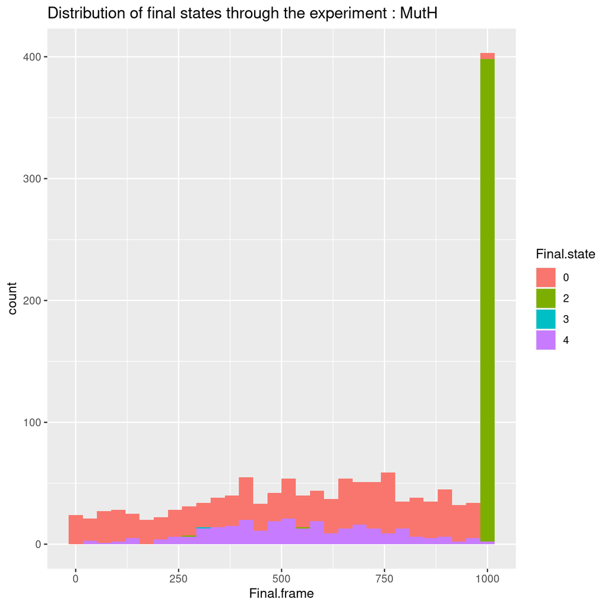

```r
summary(mortality_MutH)
options(repr.plot.res=200)
ggplot(mortality_MutH, aes(x=Final.frame, fill=Final.state))+
  geom_histogram(bins = 30) +
  ggtitle("Distribution of final states through the experiment : MutH")
```

```r
last_frame_MutH <- max(mortality_MutH$Final.frame)
survival_frame <- function(i, dataset){               # Proportion
  return (mean(dataset$Final.frame>=i, na.rm = T))
}

mortality_MutH_noEscape <- mortality_MutH[mortality_MutH$Final.state != 4,]

survival_MutH <- data.frame(Time = 0:last_frame_MutH/60*4,  # One frame every 4 minutes
                            Survival = sapply(0:last_frame_MutH, survival_frame, dataset=mortality_MutH),
                            # Correct for escaped bacteria
                            Survival_noEscape = sapply(0:last_frame_MutH, survival_frame, dataset=mortality_MutH_noEscape))
```

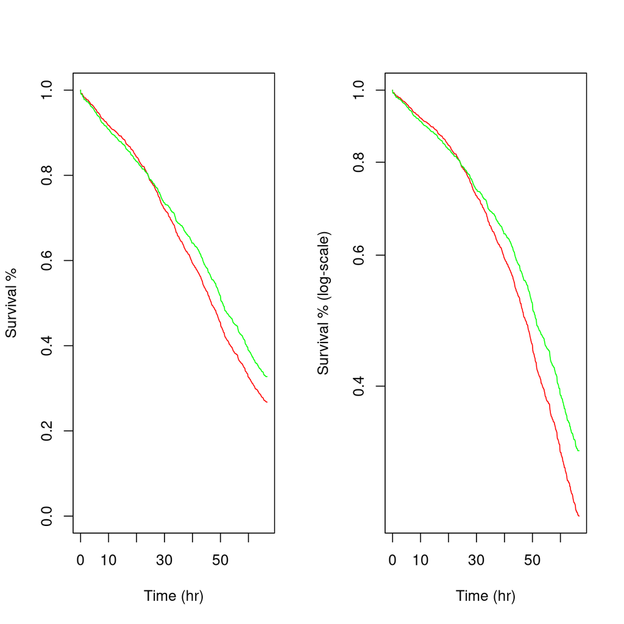

```r
par(mfrow=c(1,2))
#options(repr.plot.width = 6, repr.plot.height = 3, repr.plot.res=200)

plot(x=survival_MutH$Time,
     y=survival_MutH$Survival,
     type="l",
     col="red",
     xlab = "Time (hr)",
     ylab="Survival %",
     ylim = c(0.0001,1))
lines(x=survival_MutH$Time, y=survival_MutH$Survival_noEscape, col="green")

plot(x=survival_MutH$Time,
     y=survival_MutH$Survival,
     type="l",
     col="red",
     xlab = "Time (hr)",
     ylab="Survival % (log-scale)",
     # ylim = c(0.1,1),
     log="y")
lines(x=survival_MutH$Time, y=survival_MutH$Survival_noEscape, col="green")
```

#### All lines

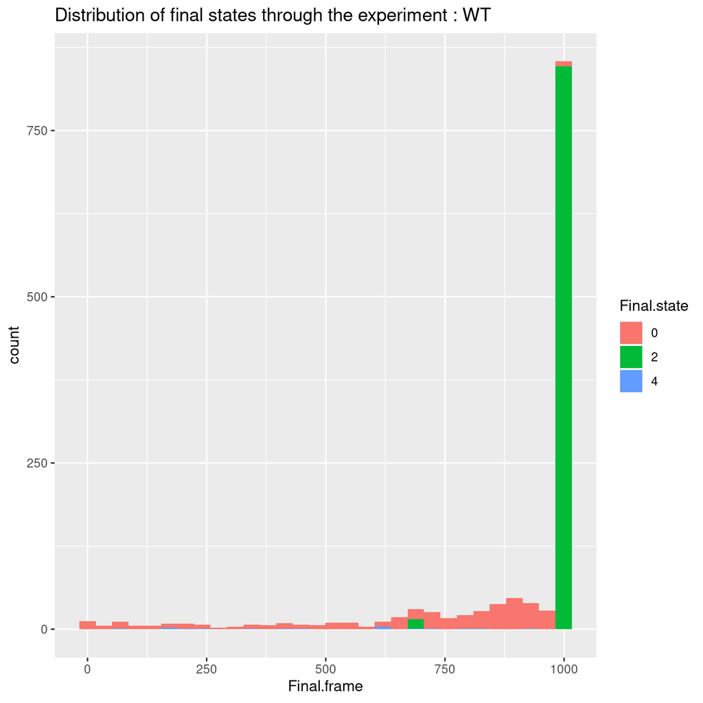

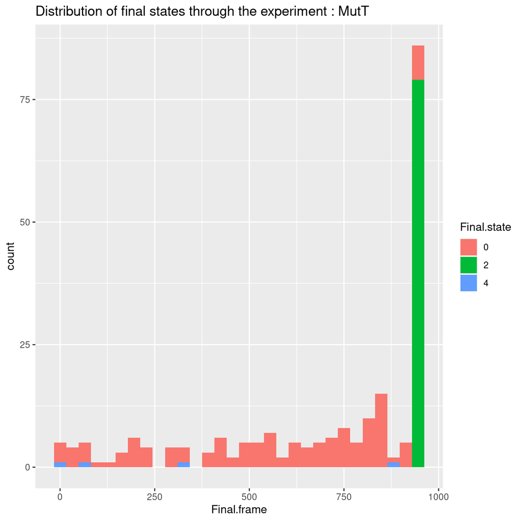

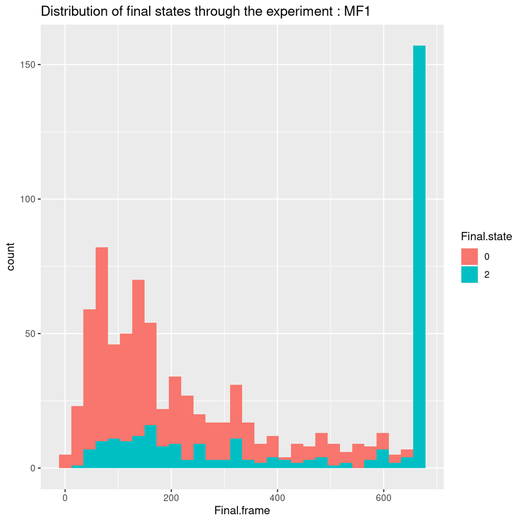

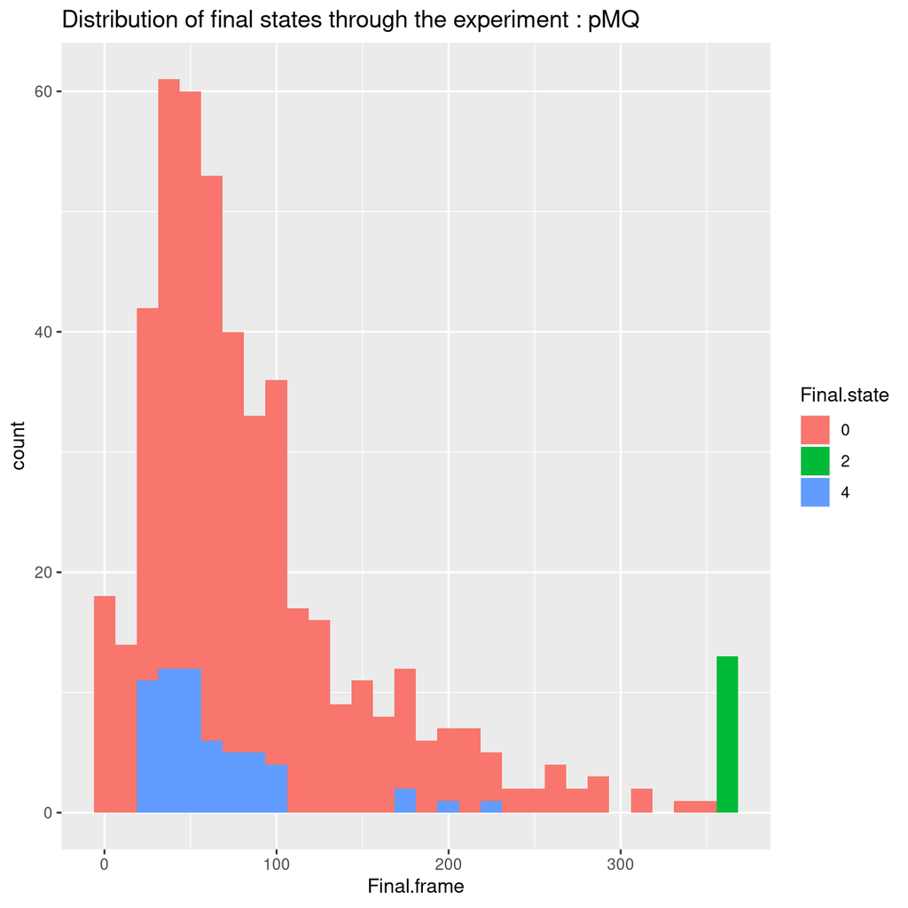

```r
par(mfrow=c(2,2))

#options(repr.plot.width = 6, repr.plot.height = 3)

ggplot(mortality_WT, aes(x=Final.frame, fill=Final.state)) +
  geom_histogram(bins = 30) +
  ggtitle("Distribution of final states through the experiment : WT")

ggplot(mortality_MutT, aes(x=Final.frame, fill=Final.state)) +
  geom_histogram(bins = 30) +
  ggtitle("Distribution of final states through the experiment : MutT")

ggplot(mortality_MF1, aes(x=Final.frame, fill=Final.state)) +
  geom_histogram(bins = 30) +
  ggtitle("Distribution of final states through the experiment : MF1")

ggplot(mortality_pMQ, aes(x=Final.frame, fill=Final.state)) +
  geom_histogram(bins = 30) +
  ggtitle("Distribution of final states through the experiment : pMQ")
```

```r
last_frame_WT <- max(mortality_WT$Final.frame)
last_frame_MutT <- max(mortality_MutT$Final.frame)
last_frame_MF1 <- max(mortality_MF1$Final.frame)
last_frame_pMQ <- max(mortality_pMQ$Final.frame)

mortality_WT_noEscape <- mortality_WT[mortality_WT$Final.state != 4,]
mortality_MutT_noEscape <- mortality_MutT[mortality_MutT$Final.state != 4,]
mortality_MF1_noEscape <- mortality_MF1[mortality_MF1$Final.state != 4,]
mortality_pMQ_noEscape <- mortality_pMQ[mortality_pMQ$Final.state != 4,]

survival_WT <- data.frame(Time = 0:last_frame_WT/60*4,  # One frame every 4 minutes
                          Survival = sapply(0:last_frame_WT, survival_frame, dataset=mortality_WT),
                          Survival_noEscape = sapply(0:last_frame_WT, survival_frame, dataset=mortality_WT_noEscape))
survival_MutT <- data.frame(Time = 0:last_frame_MutT/60*4,
                            Survival = sapply(0:last_frame_MutT, survival_frame, dataset=mortality_MutT),
                            Survival_noEscape = sapply(0:last_frame_MutT, survival_frame, dataset=mortality_MutT_noEscape))
survival_MF1 <- data.frame(Time = 0:last_frame_MF1/60*4,
                           Survival = sapply(0:last_frame_MF1, survival_frame, dataset=mortality_MF1),
                           Survival_noEscape = sapply(0:last_frame_MF1, survival_frame, dataset=mortality_MF1_noEscape))
survival_pMQ <- data.frame(Time = 0:last_frame_pMQ/60*4,
                           Survival = sapply(0:last_frame_pMQ, survival_frame, dataset=mortality_pMQ),
                           Survival_noEscape = sapply(0:last_frame_pMQ, survival_frame, dataset=mortality_pMQ_noEscape))
```

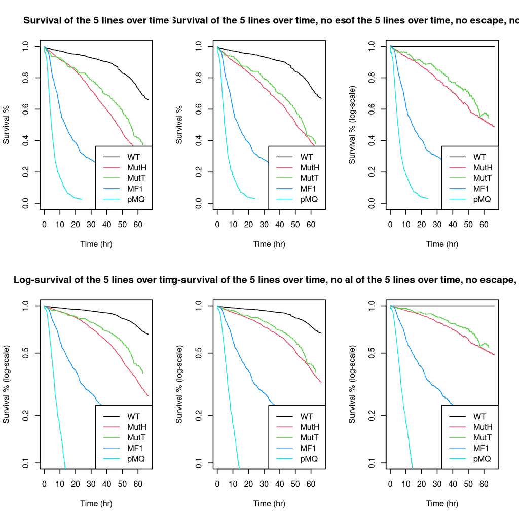

```r
par(mfrow=c(2,3))
#options(repr.plot.width = 6, repr.plot.height = 6)


plot(x=survival_WT$Time,
     y=survival_WT$Survival,
     type="l",
     col=1,
     xlab = "Time (hr)",
     ylab="Survival %",
     ylim = c(0,1),
     main = "Survival of the 5 lines over time")
lines(x=survival_MutH$Time, y=survival_MutH$Survival, col=2)
lines(x=survival_MutT$Time, y=survival_MutT$Survival, col=3)
lines(x=survival_MF1$Time, y=survival_MF1$Survival, col=4)
lines(x=survival_pMQ$Time, y=survival_pMQ$Survival, col=5)
legend("bottomright", legend = c("WT", "MutH", "MutT", "MF1", "pMQ"), col=1:5, lty=1)

plot(x=survival_WT$Time,
     y=survival_WT$Survival_noEscape,
     type="l",
     col=1,
     xlab = "Time (hr)",
     ylab="Survival %",
     ylim = c(0,1),
     main = "Survival of the 5 lines over time, no escape")
lines(x=survival_MutH$Time, y=survival_MutH$Survival_noEscape, col=2)
lines(x=survival_MutT$Time, y=survival_MutT$Survival_noEscape, col=3)
lines(x=survival_MF1$Time, y=survival_MF1$Survival_noEscape, col=4)
lines(x=survival_pMQ$Time, y=survival_pMQ$Survival_noEscape, col=5)
legend("bottomright", legend = c("WT", "MutH", "MutT", "MF1", "pMQ"), col=1:5, lty=1)

plot(x=survival_WT$Time,
     y=survival_WT$Survival_noEscape/survival_WT$Survival_noEscape,
     type="l",
     col=1,
     xlab = "Time (hr)",
     ylab="Survival % (log-scale)",
     ylim = c(0,1),
     main = "Survival of the 5 lines over time, no escape, no senescence")
lines(x=survival_MutH$Time, y=survival_MutH$Survival_noEscape/survival_WT$Survival_noEscape[1:length(survival_MutH$Survival_noEscape)], col=2)
lines(x=survival_MutT$Time, y=survival_MutT$Survival_noEscape/survival_WT$Survival_noEscape[1:length(survival_MutT$Survival_noEscape)], col=3)
lines(x=survival_MF1$Time, y=survival_MF1$Survival_noEscape/survival_WT$Survival_noEscape[1:length(survival_MF1$Survival_noEscape)], col=4)
lines(x=survival_pMQ$Time, y=survival_pMQ$Survival_noEscape/survival_WT$Survival_noEscape[1:length(survival_pMQ$Survival_noEscape)], col=5)
legend("bottomright", legend = c("WT", "MutH", "MutT", "MF1", "pMQ"), col=1:5, lty=1)

plot(x=survival_WT$Time,
     y=survival_WT$Survival,
     type="l",
     col=1,
     xlab = "Time (hr)",
     ylab="Survival % (log-scale)",
     ylim = c(0.1,1),
     log = "y",
     main = "Log-survival of the 5 lines over time")
lines(x=survival_MutH$Time, y=survival_MutH$Survival, col=2)
lines(x=survival_MutT$Time, y=survival_MutT$Survival, col=3)
lines(x=survival_MF1$Time, y=survival_MF1$Survival, col=4)
lines(x=survival_pMQ$Time, y=survival_pMQ$Survival, col=5)
legend("bottomright", legend = c("WT", "MutH", "MutT", "MF1", "pMQ"), col=1:5, lty=1)

plot(x=survival_WT$Time,
     y=survival_WT$Survival_noEscape,
     type="l",
     col=1,
     xlab = "Time (hr)",
     ylab="Survival % (log-scale)",
     ylim = c(0.1,1),
     log="y",
     main = "Log-survival of the 5 lines over time, no escape")
lines(x=survival_MutH$Time, y=survival_MutH$Survival_noEscape, col=2)
lines(x=survival_MutT$Time, y=survival_MutT$Survival_noEscape, col=3)
lines(x=survival_MF1$Time, y=survival_MF1$Survival_noEscape, col=4)
lines(x=survival_pMQ$Time, y=survival_pMQ$Survival_noEscape, col=5)
legend("bottomright", legend = c("WT", "MutH", "MutT", "MF1", "pMQ"), col=1:5, lty=1)

plot(x=survival_WT$Time,
     y=survival_WT$Survival_noEscape/survival_WT$Survival_noEscape,
     type="l",
     col=1,
     xlab = "Time (hr)",
     ylab="Survival % (log-scale)",
     ylim = c(0.1,1),
     log="y",
     main = "Log-survival of the 5 lines over time, no escape, no senescence")
lines(x=survival_MutH$Time, y=survival_MutH$Survival_noEscape/survival_WT$Survival_noEscape[1:length(survival_MutH$Survival_noEscape)], col=2)
lines(x=survival_MutT$Time, y=survival_MutT$Survival_noEscape/survival_WT$Survival_noEscape[1:length(survival_MutT$Survival_noEscape)], col=3)
lines(x=survival_MF1$Time, y=survival_MF1$Survival_noEscape/survival_WT$Survival_noEscape[1:length(survival_MF1$Survival_noEscape)], col=4)
lines(x=survival_pMQ$Time, y=survival_pMQ$Survival_noEscape/survival_WT$Survival_noEscape[1:length(survival_pMQ$Survival_noEscape)], col=5)
legend("bottomright", legend = c("WT", "MutH", "MutT", "MF1", "pMQ"), col=1:5, lty=1)
```

### Growth rates

#### MutH

```r
head(microMA_MutH[,1:9])
```

A data.frame: 6 × 9

|  | time <int> | generation <int> | growth.rate <dbl> | time.1 <int> | generation.1 <int> | growth.rate.1 <dbl> | time.2 <int> | generation.2 <int> | growth.rate.2 <dbl> |
| --- | --- | --- | --- | --- | --- | --- | --- | --- | --- |
| 3 | 0 | 1 | 0.03526965 | 0 | 1 | 0.03202591 | 0 | 1 | 0.02811950 |
| 4 | 4 | 1 | 0.03526965 | 4 | 1 | 0.03202591 | 4 | 1 | 0.02811950 |
| 5 | 8 | 2 | 0.03247045 | 8 | 1 | 0.03202591 | 8 | 2 | 0.02680181 |
| 6 | 12 | 2 | 0.03247045 | 12 | 1 | 0.03202591 | 12 | 2 | 0.02680181 |
| 7 | 16 | 2 | 0.03247045 | 16 | 2 | 0.03367152 | 16 | 2 | 0.02680181 |
| 8 | 20 | 2 | 0.03247045 | 20 | 2 | 0.03367152 | 20 | 2 | 0.02680181 |

```r
summary(microMA_MutH[,1:9])
```

```
      time        generation      growth.rate          time.1
 Min.   :   0   Min.   :  1.00   Min.   :0.01835   Min.   :   0
 1st Qu.: 999   1st Qu.: 45.00   1st Qu.:0.02770   1st Qu.: 999
 Median :1998   Median : 90.00   Median :0.02883   Median :1998
 Mean   :1998   Mean   : 90.82   Mean   :0.02974   Mean   :1998
 3rd Qu.:2997   3rd Qu.:136.00   3rd Qu.:0.03127   3rd Qu.:2997
 Max.   :3996   Max.   :183.00   Max.   :0.07248   Max.   :3996
  generation.1   growth.rate.1         time.2      generation.2
 Min.   :  1.0   Min.   :0.01148   Min.   :   0   Min.   :  1.00
 1st Qu.: 36.0   1st Qu.:0.01650   1st Qu.: 999   1st Qu.: 48.75
 Median : 63.0   Median :0.01753   Median :1998   Median : 97.00
 Mean   : 63.8   Mean   :0.01859   Mean   :1998   Mean   : 91.61
 3rd Qu.: 92.0   3rd Qu.:0.01944   3rd Qu.:2997   3rd Qu.:140.00
 Max.   :122.0   Max.   :0.03386   Max.   :3996   Max.   :165.00
 growth.rate.2
 Min.   :-0.0009553
 1st Qu.: 0.0252990
 Median : 0.0290788
 Mean   : 0.0240472
 3rd Qu.: 0.0314002
 Max.   : 0.0927149
```

```r
microMA_MutH_growthRates <- microMA_MutH[seq(3, dim(microMA_MutH)[1], 3)]

moment_expectation <- function(k, dataset){
  return (rowMeans(dataset**k, na.rm = T))
}

k_values <- 1:10
moments_expectations_MutH <- data.frame(sapply(k_values, moment_expectation, dataset=microMA_MutH_growthRates))
names(moments_expectations_MutH) <- paste("k.", k_values, sep = "")
head(moments_expectations_MutH)
```

A data.frame: 6 × 10

|  | k.1 <dbl> | k.2 <dbl> | k.3 <dbl> | k.4 <dbl> | k.5 <dbl> | k.6 <dbl> | k.7 <dbl> | k.8 <dbl> | k.9 <dbl> | k.10 <dbl> |
| --- | --- | --- | --- | --- | --- | --- | --- | --- | --- | --- |
| 3 | 0.03137447 | 0.0010032700 | 3.251881e-05 | 1.066829e-06 | 3.539456e-08 | 1.186858e-09 | 4.020415e-11 | 1.375217e-12 | 4.748269e-14 | 1.654292e-15 |
| 4 | 0.03130396 | 0.0009998646 | 3.235306e-05 | 1.059208e-06 | 3.505972e-08 | 1.172581e-09 | 3.960677e-11 | 1.350511e-12 | 4.646825e-14 | 1.612815e-15 |
| 5 | 0.03133240 | 0.0010003611 | 3.226211e-05 | 1.050351e-06 | 3.450651e-08 | 1.143443e-09 | 3.820324e-11 | 1.286428e-12 | 4.364179e-14 | 1.491033e-15 |
| 6 | 0.03127231 | 0.0009965875 | 3.208534e-05 | 1.043040e-06 | 3.422552e-08 | 1.133199e-09 | 3.784594e-11 | 1.274498e-12 | 4.326276e-14 | 1.479768e-15 |
| 7 | 0.03114305 | 0.0009878136 | 3.163678e-05 | 1.022574e-06 | 3.334669e-08 | 1.096837e-09 | 3.637811e-11 | 1.216262e-12 | 4.098122e-14 | 1.391229e-15 |
| 8 | 0.03121328 | 0.0009931178 | 3.191967e-05 | 1.035682e-06 | 3.391273e-08 | 1.120357e-09 | 3.733480e-11 | 1.254727e-12 | 4.251900e-14 | 1.452577e-15 |

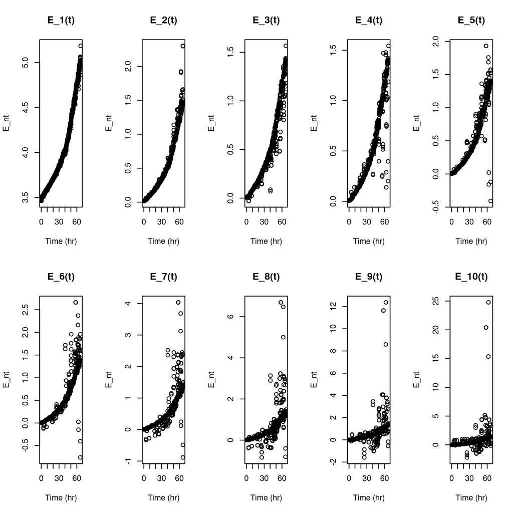

```r
log_choose <- function(k, n, moments_expectations){
  return ((-1)**k*choose(n,k)*log(moments_expectations[,k]))
}

par(mfrow = c(2,5))
#options(repr.plot.width = 8, repr.plot.height = 5)

for (n in 1:10){
  E_nt <- rowSums(sapply(1:n, log_choose, n=n, moments_expectations=moments_expectations_MutH))
  plot(x = microMA_MutH$time/60,
       y = E_nt,
       xlab = "Time (hr)",
       main = paste("E_", n, "(t)", sep = ""))
}
```

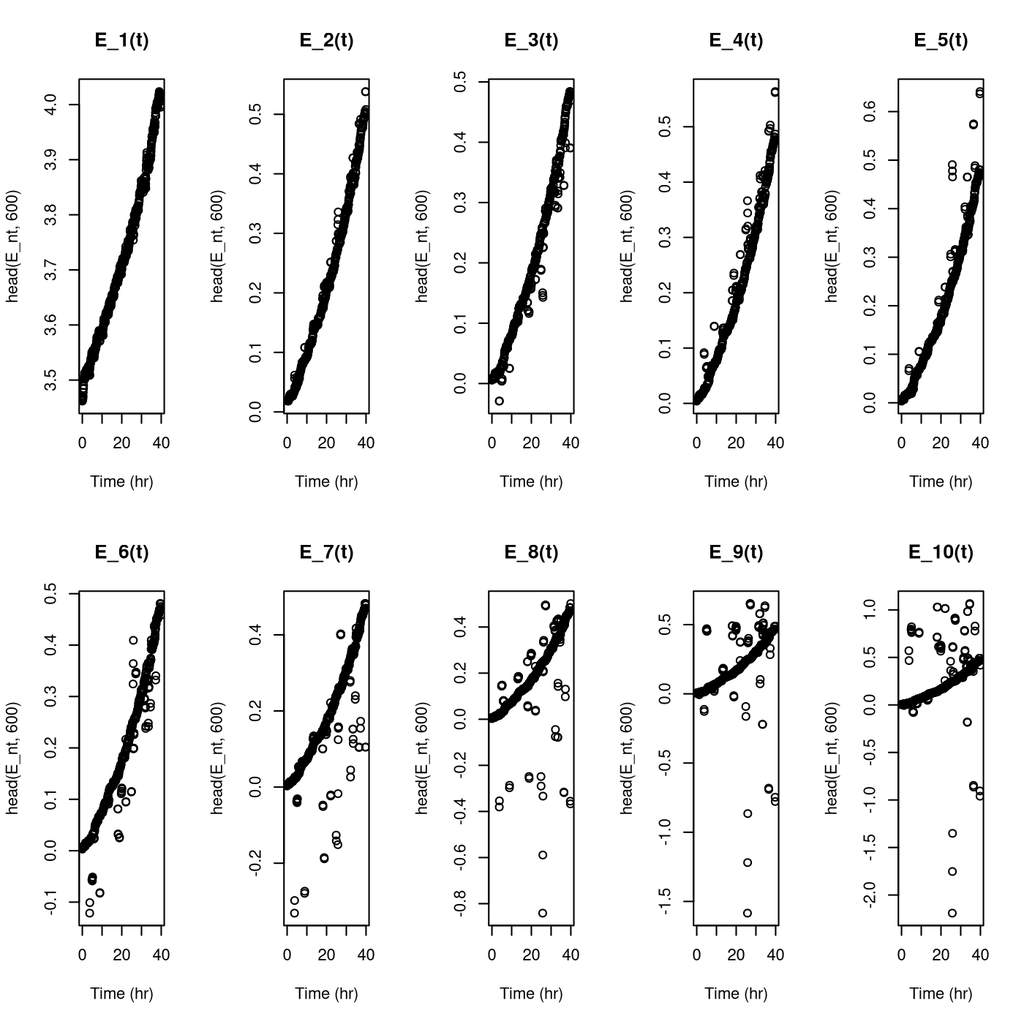

```r
par(mfrow = c(2,5))
#options(repr.plot.width = 8, repr.plot.height = 5)

for (n in 1:10){
  E_nt <- rowSums(sapply(1:n, log_choose, n=n, moments_expectations=moments_expectations_MutH))
  plot(x = head(microMA_MutH$time/60, 600),
       y = head(E_nt, 600),
       xlab = "Time (hr)",
       main = paste("E_", n, "(t)", sep = ""))
}
```

#### WT

```r
head(microMA_WT[,1:9])
```

A data.frame: 6 × 9

|  | time <int> | generation <int> | growth.rate <dbl> | time.1 <int> | generation.1 <int> | growth.rate.1 <dbl> | time.2 <int> | generation.2 <int> | growth.rate.2 <dbl> |
| --- | --- | --- | --- | --- | --- | --- | --- | --- | --- |
| 3 | 0 | 1 | 0.01553294 | 0 | 1 | NA | 0 | 1 | NA |
| 4 | 4 | 1 | 0.01553294 | 4 | 2 | 0.03227775 | 4 | 2 | 0.03030216 |
| 5 | 8 | 2 | 0.03122056 | 8 | 2 | 0.03227775 | 8 | 2 | 0.03030216 |
| 6 | 12 | 2 | 0.03122056 | 12 | 2 | 0.03227775 | 12 | 2 | 0.03030216 |
| 7 | 16 | 2 | 0.03122056 | 16 | 2 | 0.03227775 | 16 | 2 | 0.03030216 |
| 8 | 20 | 2 | 0.03122056 | 20 | 2 | 0.03227775 | 20 | 2 | 0.03030216 |

```r
microMA_WT_growthRates <- microMA_WT[seq(3, dim(microMA_WT)[1], 3)]

k_values <- 1:10
moments_expectations_WT <- data.frame(sapply(k_values, moment_expectation, dataset=microMA_WT_growthRates))
names(moments_expectations_WT) <- paste("k.", k_values, sep = "")
head(moments_expectations_WT)
```

A data.frame: 6 × 10

|  | k.1 <dbl> | k.2 <dbl> | k.3 <dbl> | k.4 <dbl> | k.5 <dbl> | k.6 <dbl> | k.7 <dbl> | k.8 <dbl> | k.9 <dbl> | k.10 <dbl> |
| --- | --- | --- | --- | --- | --- | --- | --- | --- | --- | --- |
| 3 | 0.04042723 | 0.003156244 | 5.905593e-04 | 1.748746e-04 | 6.102199e-05 | 2.292541e-05 | 8.973667e-06 | 3.599604e-06 | 1.465553e-06 | 6.021423e-07 |
| 4 | 0.03860821 | 0.002765079 | 4.872849e-04 | 1.422165e-04 | 4.950406e-05 | 1.859016e-05 | 7.276109e-06 | 2.918612e-06 | 1.188287e-06 | 4.882236e-07 |
| 5 | 0.03470470 | 0.001544387 | 1.011044e-04 | 1.004379e-05 | 1.312441e-06 | 1.971840e-07 | 3.185680e-08 | 5.370909e-09 | 9.307349e-10 | 1.643254e-10 |
| 6 | 0.03282946 | 0.001308177 | 7.368765e-05 | 6.756946e-06 | 9.017820e-07 | 1.441027e-07 | 2.481577e-08 | 4.418484e-09 | 7.999427e-10 | 1.461470e-10 |
| 7 | 0.03137282 | 0.001105509 | 4.538313e-05 | 2.336099e-06 | 1.548754e-07 | 1.252336e-08 | 1.139606e-09 | 1.103166e-10 | 1.103137e-11 | 1.123628e-12 |
| 8 | 0.03030172 | 0.001023872 | 4.020719e-05 | 2.015404e-06 | 1.346936e-07 | 1.122403e-08 | 1.054261e-09 | 1.046304e-10 | 1.064968e-11 | 1.098019e-12 |

A matrix: 999 × 5 of type dbl

[output not shown]

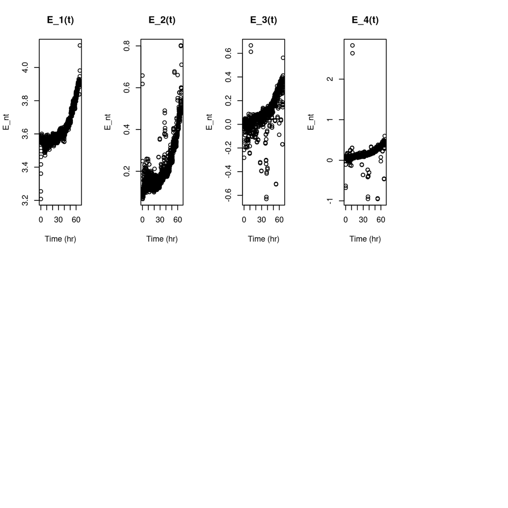

```r
par(mfrow = c(2,5))
#options(repr.plot.width = 8, repr.plot.height = 5)

for (n in 1:4){
  E_nt <- rowSums(sapply(1:n, log_choose, n=n, moments_expectations=moments_expectations_WT))
  plot(x = microMA_WT$time/60,
       y = E_nt,
       xlab = "Time (hr)",
       main = paste("E_", n, "(t)", sep = ""))
}
sapply(1:5, log_choose, n=n, moments_expectations=moments_expectations_WT)
```

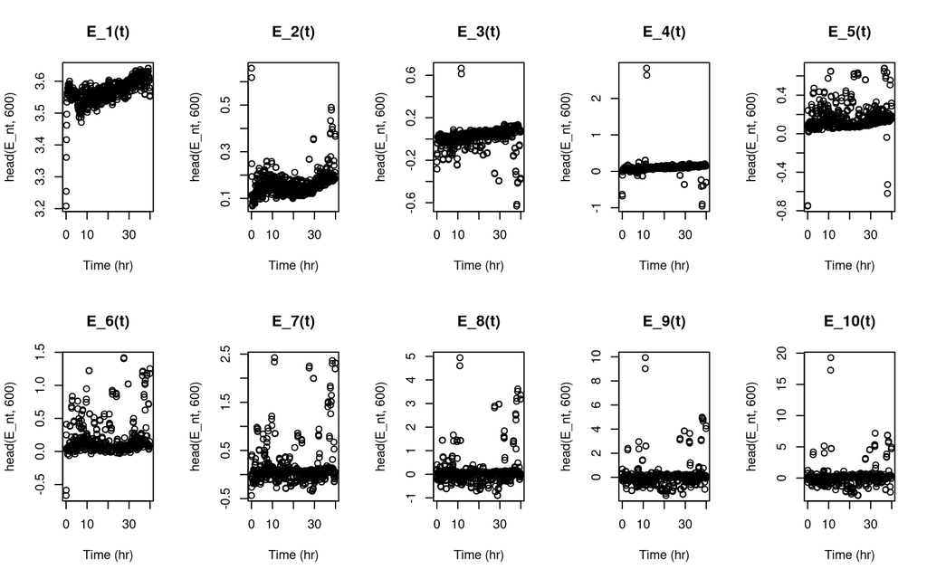

```r
par(mfrow = c(2,5))
options(repr.plot.width = 8, repr.plot.height = 5)

for (n in 1:10){
  E_nt <- rowSums(sapply(1:n, log_choose, n=n, moments_expectations=moments_expectations_WT))
  plot(x = head(microMA_WT$time/60, 600),
       y = head(E_nt, 600),
       xlab = "Time (hr)",
       main = paste("E_", n, "(t)", sep = ""))
}
```

#### WT + MutH

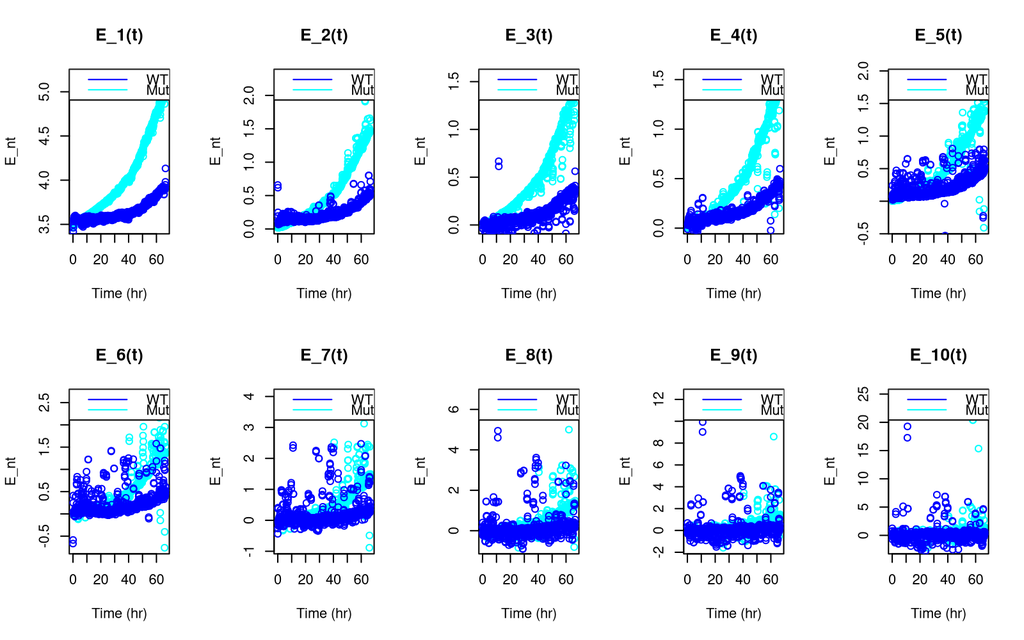

```r
par(mfrow = c(2,5))
#options(repr.plot.width = 8, repr.plot.height = 5)

for (n in 1:10){
  E_nt <- rowSums(sapply(1:n, log_choose, n=n, moments_expectations=moments_expectations_MutH))
  plot(x = microMA_MutH$time/60,
       y = E_nt,
       xlab = "Time (hr)",
       col = "cyan",
       main = paste("E_", n, "(t)", sep = ""))

  E_nt <- rowSums(sapply(1:n, log_choose, n=n, moments_expectations=moments_expectations_WT))
  points(x = microMA_WT$time/60,
       y = E_nt,
       xlab = "Time (hr)",
       col = "blue",
       main = paste("E_", n, "(t)", sep = ""))

  legend("topleft", legend = c("WT", "MutH"), col=c("blue", "cyan"), lty=1)
}
```

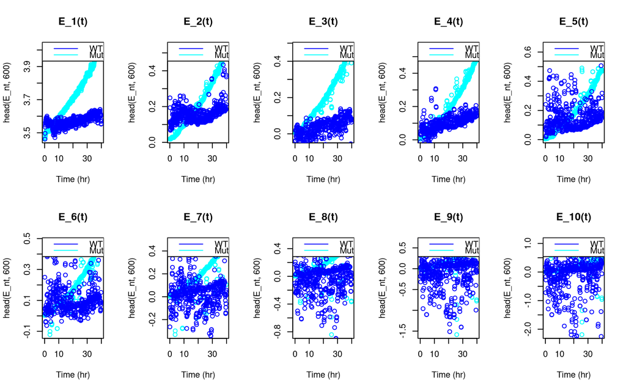

```r
par(mfrow = c(2,5))
#options(repr.plot.width = 8, repr.plot.height = 5)

for (n in 1:10){
  E_nt <- rowSums(sapply(1:n, log_choose, n=n, moments_expectations=moments_expectations_MutH))
  plot(x = head(microMA_MutH$time/60, 600),
       y = head(E_nt, 600),
       xlab = "Time (hr)",
       col = "cyan",
       main = paste("E_", n, "(t)", sep = ""))

  E_nt <- rowSums(sapply(1:n, log_choose, n=n, moments_expectations=moments_expectations_WT))
  points(x = head(microMA_WT$time/60, 600),
       y = head(E_nt, 600),
       xlab = "Time (hr)",
       col = "blue",
       main = paste("E_", n, "(t)", sep = ""))

  legend("topleft", legend = c("WT", "MutH"), col=c("blue", "cyan"), lty=1)
}
```

## Mutation Visualization data : data_MV

### Files description

"interarrival_times_figure2" gives the inter-arrival times between successive foci (in minutes) for a mutH experiment

A data.frame: 6 × 1

|  | inter_time <int> |
| --- | --- |
| 1 | 0 |
| 2 | 8 |
| 3 | 12 |
| 4 | 4 |
| 5 | 12 |
| 6 | 8 |

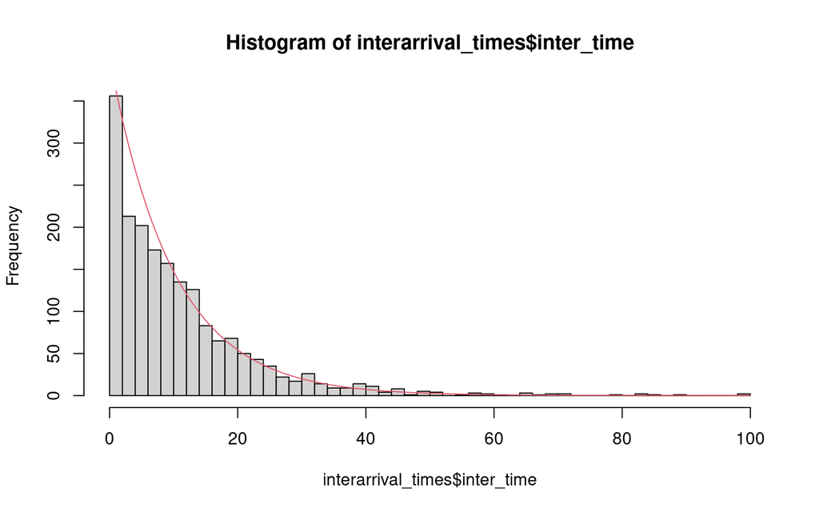

```r
interarrival_times <- read.csv2("doi_10/All_data/data_MV/interarrival_times_figure2.csv")
names(interarrival_times) <- c("inter_time")
head(interarrival_times)
hist(interarrival_times$inter_time,breaks=40)

x=1:100
y=sapply(x,function(x) 400*exp(-0.1*x))
lines(x,y,col=2)
```

"size_and_focusfirstdetection_figure2E" gives the size and number of new foci for all mother cells at all times, for a mutH experiment (number new foci at time ti = number of foci that arose between ti-1 and ti)

```r
size_nfoci <- read.csv2("./doi_10/All_data/data_MV/size_and_focusfirstdetection_figure2E.csv")
names(size_nfoci)=c("cell_size","nfoci")
head(size_nfoci)
summary(size_nfoci)
```

A data.frame: 6 × 2

|  | cell_size <dbl> | nfoci <int> |
| --- | --- | --- |
| 1 | 2.9968 | 0 |
| 2 | 3.1351 | 0 |
| 3 | 3.3530 | 0 |
| 4 | 3.5081 | 0 |
| 5 | 3.7177 | 0 |
| 6 | 4.0362 | 0 |

```
   cell_size          nfoci
 Min.   : 2.578   Min.   :0.00000
 1st Qu.: 3.424   1st Qu.:0.00000
 Median : 4.053   Median :0.00000
 Mean   : 4.220   Mean   :0.09278
 3rd Qu.: 4.832   3rd Qu.:0.00000
 Max.   :22.302   Max.   :3.00000
```

```r
sum(size_nfoci$nfoci==1)
sum(size_nfoci$nfoci==2)
sum(size_nfoci$nfoci==3)
```

7060

195

3

$\to$ We may forget cells with 2 foci or more (for the MutH experiment)

" size_growthrate_focusfirstdetection_figure2G" gives the size, growth rate and number of new foci for all mother cells at all times, for mutH (2 experiments are pooled; number new foci at time ti = number of foci that arose between ti-1 and ti)

```r
size_grate_nfoci<-read.csv2("doi_10/All_data/data_MV/size_growthrate_focusfirstdetection_figure2G.csv")

names(size_grate_nfoci)=c("size","grate","nfoci")
head(size_grate_nfoci)
summary(size_grate_nfoci)
```

A data.frame: 6 × 3

|  | size <dbl> | grate <dbl> | nfoci <int> |
| --- | --- | --- | --- |
| 1 | 5.4151 | 0.02826265 | 0 |
| 2 | 2.8794 | 0.02875155 | 0 |
| 3 | 2.9968 | 0.02875155 | 0 |
| 4 | 3.1351 | 0.02875155 | 0 |
| 5 | 3.3530 | 0.02875155 | 0 |
| 6 | 3.5081 | 0.02875155 | 0 |

```
      size             grate               nfoci
 Min.   : 0.7502   Min.   :0.0001932   Min.   :0.0000
 1st Qu.: 3.3111   1st Qu.:0.0211233   1st Qu.:0.0000
 Median : 4.0404   Median :0.0251375   Median :0.0000
 Mean   : 4.3201   Mean   :0.0232383   Mean   :0.0805
 3rd Qu.: 4.9499   3rd Qu.:0.0273565   3rd Qu.:0.0000
 Max.   :24.2004   Max.   :0.0334957   Max.   :4.0000
```

```r
sum(size_nfoci$nfoci==1)
sum(size_nfoci$nfoci==2)
sum(size_nfoci$nfoci==3)
```

7060

195

3

# Data Analysis

## Stepwise growth rate drops

```r
dim(microMA_MutH_growthRates)
head(microMA_MutH_growthRates)
```

1. 1000

2. 333

A data.frame: 6 × 333

|  | growth.rate <dbl> | growth.rate.1 <dbl> | growth.rate.2 <dbl> | growth.rate.3 <dbl> | growth.rate.4 <dbl> | growth.rate.5 <dbl> | growth.rate.6 <dbl> | growth.rate.7 <dbl> | growth.rate.8 <dbl> | growth.rate.9 <dbl> | ⋯ | growth.rate.323 <dbl> | growth.rate.324 <dbl> | growth.rate.325 <dbl> | growth.rate.326 <dbl> | growth.rate.327 <dbl> | growth.rate.328 <dbl> | growth.rate.329 <dbl> | growth.rate.330 <dbl> | growth.rate.331 <dbl> | growth.rate.332 <dbl> |
| --- | --- | --- | --- | --- | --- | --- | --- | --- | --- | --- | --- | --- | --- | --- | --- | --- | --- | --- | --- | --- | --- |
| 3 | 0.03526965 | 0.03202591 | 0.02811950 | 0.02976484 | NA | NA | 0.03168793 | 0.02793259 | 0.03028918 | NA | ⋯ | NA | 0.03494049 | 0.03055465 | 0.02411416 | NA | 0.03526965 | 0.02709379 | 0.02819887 | 0.01534224 | 0.03674442 |
| 4 | 0.03526965 | 0.03202591 | 0.02811950 | 0.02976484 | 0.03381196 | 0.03075045 | 0.03168793 | 0.02793259 | 0.03028918 | 0.031277 | ⋯ | 0.02771285 | 0.03494049 | 0.03055465 | 0.02411416 | 0.03539149 | 0.03526965 | 0.02709379 | 0.02819887 | 0.01534224 | 0.03674442 |
| 5 | 0.03247045 | 0.03202591 | 0.02680181 | 0.03056693 | 0.03381196 | 0.03075045 | 0.02882748 | 0.02793259 | 0.03028918 | 0.031277 | ⋯ | 0.02771285 | 0.02420190 | 0.03055465 | 0.02411416 | 0.03539149 | 0.03079581 | 0.02709379 | 0.02962824 | 0.03153608 | 0.03674442 |
| 6 | 0.03247045 | 0.03202591 | 0.02680181 | 0.03056693 | 0.03381196 | 0.03075045 | 0.02882748 | 0.02793259 | 0.03254053 | 0.031277 | ⋯ | 0.02771285 | 0.02420190 | 0.03055465 | 0.02411416 | 0.03539149 | 0.03079581 | 0.02709379 | 0.02962824 | 0.03153608 | 0.03674442 |
| 7 | 0.03247045 | 0.03367152 | 0.02680181 | 0.03056693 | 0.03381196 | 0.03075045 | 0.02882748 | 0.02793259 | 0.03254053 | 0.031277 | ⋯ | 0.02771285 | 0.02420190 | 0.03055465 | 0.02411416 | 0.03539149 | 0.03079581 | 0.03083046 | 0.02962824 | 0.03153608 | 0.03674442 |
| 8 | 0.03247045 | 0.03367152 | 0.02680181 | 0.03056693 | 0.03219097 | 0.03075045 | 0.02882748 | 0.03294330 | 0.03254053 | 0.031277 | ⋯ | 0.02771285 | 0.02420190 | 0.03120683 | 0.02411416 | 0.03040696 | 0.03079581 | 0.03083046 | 0.02962824 | 0.03153608 | 0.03132949 |

### Gross drops : s=W'-W

40627

```
    Min.  1st Qu.   Median     Mean  3rd Qu.     Max.     NA's
-0.34244 -0.00253 -0.00005 -0.00015  0.00238  0.31194      294
```

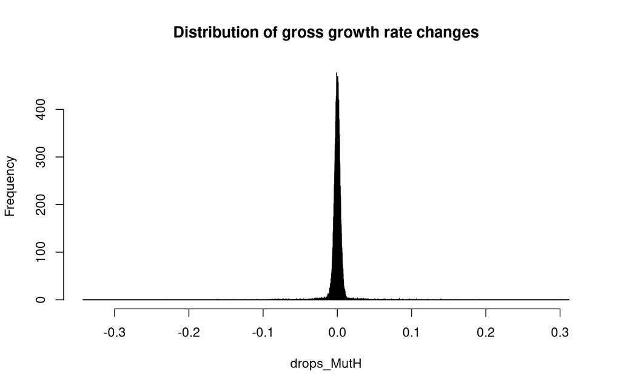

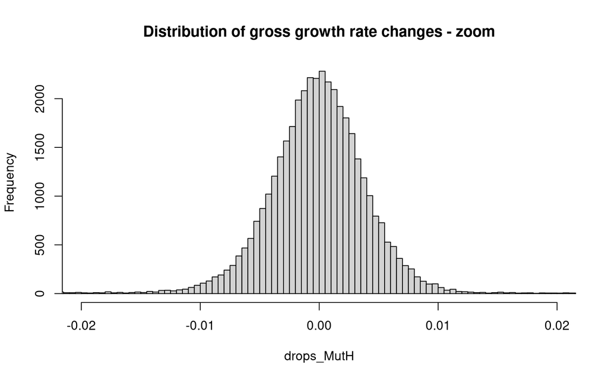

```r
get_drops_col <- function(k, dataset){
    cur_col <- dataset[,k]
    n <- length(cur_col)
    ### tu pourras m'expliquer comment ça marche sapply ?
    #res <- sapply(1:n-1,
    #              function(i) cur_col[i+1]-cur_col[i])
    res<-cur_col
    for(i in 1:n-1){
        res[i]<-cur_col[i+1]-cur_col[i]
    }
    return (res[res!=0])
}

get_drops <- function(dataset){
    ncol <- dim(dataset)[2]
    res=get_drops_col(1,dataset) ### ugly : can't do better?
    for(k in 2:ncol){
        nouv=get_drops_col(k,dataset)
        res=c(res,nouv)
    }
    return (res)
}
drops_MutH <- get_drops(microMA_MutH_growthRates)

length(drops_MutH)
summary(drops_MutH)
hist(drops_MutH,breaks=5000,
    main="Distribution of gross growth rate changes")
hist(drops_MutH,breaks=1000,
     xlim=c(-0.02,0.02),
    main="Distribution of gross growth rate changes - zoom")
```

```
	Shapiro-Wilk normality test

data:  drops_MutH_norm[1:5000]
W = 0.5357, p-value < 2.2e-16
```

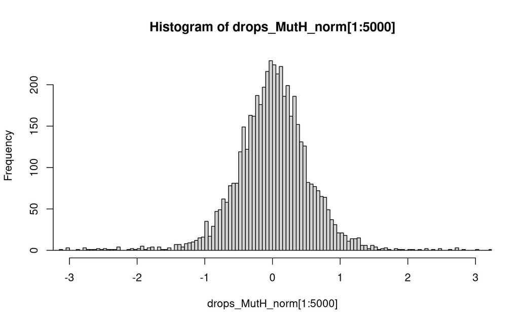

```r
# test de gaussianité :
drops_MutH_sd=sd(drops_MutH[1:5000],na.rm=TRUE)
drops_MutH_mean=mean(drops_MutH[1:5000],na.rm=TRUE)
drops_MutH_norm=(drops_MutH-drops_MutH_mean)/drops_MutH_sd
hist(drops_MutH_norm[1:5000],xlim=c(-3,3),breaks=1000)
shapiro.test(drops_MutH_norm[1:5000])
# pas du tout, pourtant on dirait beaucoup ! (me serais-je trompé ?)
```

### Relative drops : s=(W'-W)/W

40301

```
    Min.  1st Qu.   Median     Mean  3rd Qu.     Max.     NA's
-3.33723 -0.08240 -0.00160  0.00474  0.08275 24.95528      276
```

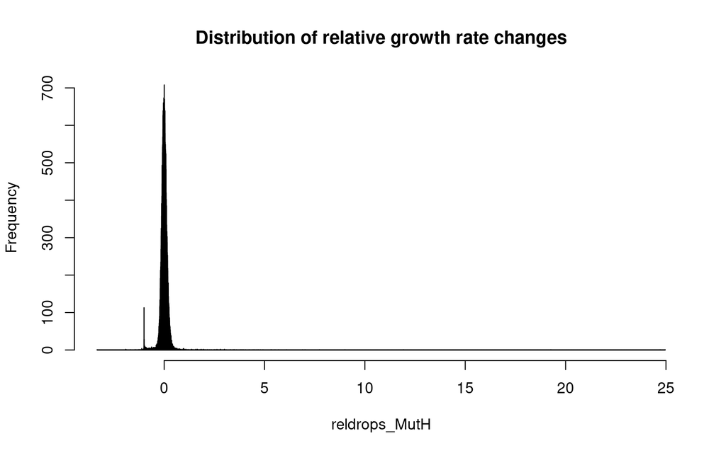

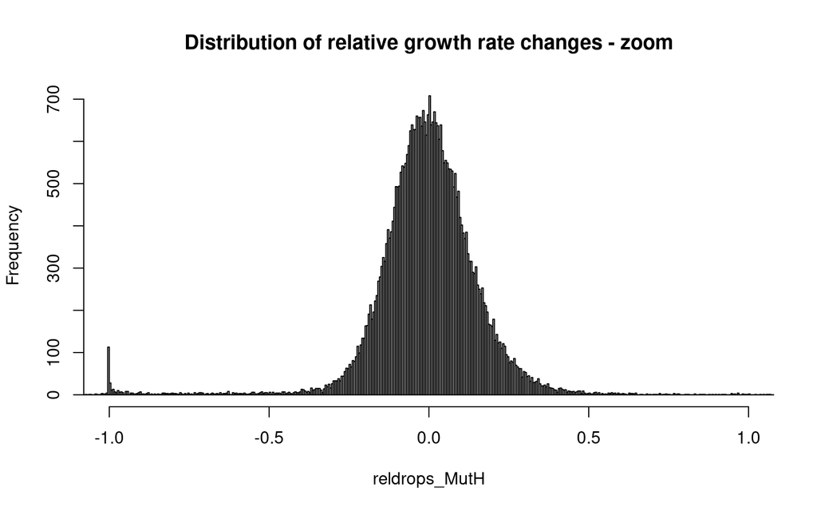

```r
get_reldrops_col <- function(k, dataset){
    cur_col <- dataset[,k]
    n <- length(cur_col)
    ### tu pourras m'expliquer comment ça marche sapply ?
    #res <- sapply(1:n-1,
    #              function(i) cur_col[i+1]-cur_col[i])
    res<-cur_col
    for(i in 1:n-1){
        ifelse(cur_col[i]>5e-3,
               res[i]<-(cur_col[i+1]-cur_col[i])/cur_col[i],
               res[i]<-0
            )
    }
    return (res[res!=0])
}

get_reldrops <- function(dataset){
    ncol <- dim(dataset)[2]
    res=get_reldrops_col(1,dataset) ### ugly : can't do better?
    for(k in 2:ncol){
        nouv=get_reldrops_col(k,dataset)
        res=c(res,nouv)
    }
    return (res)
}
reldrops_MutH <- get_reldrops(microMA_MutH_growthRates)

length(reldrops_MutH)
summary(reldrops_MutH)
hist(reldrops_MutH,breaks=5000,
    main="Distribution of relative growth rate changes")
hist(reldrops_MutH,breaks=5000,
     xlim=c(-1,1),
    main="Distribution of relative growth rate changes - zoom")
```

$\to$ This shape is quite surprising, as it does not correspond to what was expected...